# Final Project

Jess

April 5, 2017

## Overview

In this document we will show how we predict how well someone performed an activity based on their data from a personal fitness tracker. We will use two different models, trees and random forest, and compared their accuracy. The data from this project comes from [link](http://groupware.les.inf.puc-rio.br/har).

## Reading the data

First we read in the training and test data and load the caret package

```r
training<-read.csv("pml-training.csv")
testing <-read.csv("pml-testing.csv")
library(caret)
```

## Separate into trainging and validation datasets

We need to separate the data in to a training set to train the model on, and a validation set to test if the model is accurate or not. The test set is for the final test. Here we separate the data into 70/30 portions.

```r
inTrain <- createDataPartition(y=training$classe,p=0.7,list=FALSE)
mytrain <- training[inTrain,]
validation <- training[-inTrain,]
```

## Cleaning the data

Many of the variables have lots of missing data points, or they don’t really vary, which means they won’t be useful to the analysis. We need to get rid of these points before using them to predict.

Everything we do to the training set, we need to also do to the validation and test sets.

First we remove columns with little to no variaiton, because they won’t help us predict.

```r
zerovar <- nearZeroVar(mytrain)
mytrain <- mytrain[,-zerovar]
validation <- validation[,-zerovar]
test <- testing[,-zerovar]
```

Next we remove the first few columns that are useless to the model (timestamps and such).

```r
smalltrain <- mytrain[,-c(1:6)]
smallvalid <- validation[,-c(1:6)] ;
smalltest <- test[,-c(1:6)]
```

And finally, we remove the columns that have NAs in them

```r
nonas <- colSums(is.na(smalltrain))==0
smalltrain <- smalltrain[,nonas]
smallvalid <- smallvalid[,nonas]
smalltest <- smalltest[,nonas]
```

## Predicting with Trees

For our first model, we’ll try predicting with trees using Rpart.

```r
modtree <- train(classe~.,method="rpart",data=smalltrain)
```

A plot of the tree model

```r
library(rattle)
```

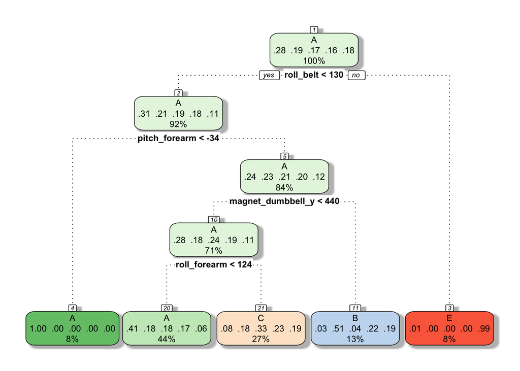

```r
fancyRpartPlot(modtree$finalModel,sub="")
```

Now we predict on the validation set and determine the accuracy

```r
predtree <- predict(modtree,smallvalid)
confusionMatrix(smallvalid$classe,predtree)
```

```
## Confusion Matrix and Statistics
##
##           Reference
## Prediction    A    B    C    D    E
##          A 1521   23  122    0    8
##          B  461  384  294    0    0
##          C  474   38  514    0    0
##          D  437  164  363    0    0
##          E  160  139  292    0  491
##
## Overall Statistics
##
##                Accuracy : 0.4945
##                  95% CI : (0.4816, 0.5073)
##     No Information Rate : 0.5188
##     P-Value [Acc > NIR] : 0.9999
##
##                   Kappa : 0.3394
##  Mcnemar's Test P-Value : NA
##
## Statistics by Class:
##
##                      Class: A Class: B Class: C Class: D Class: E
## Sensitivity            0.4982  0.51337  0.32429       NA  0.98397
## Specificity            0.9460  0.85303  0.88093   0.8362  0.89027
## Pos Pred Value         0.9086  0.33714  0.50097       NA  0.45379
## Neg Pred Value         0.6362  0.92330  0.77958       NA  0.99833
## Prevalence             0.5188  0.12710  0.26933   0.0000  0.08479
## Detection Rate         0.2585  0.06525  0.08734   0.0000  0.08343
## Detection Prevalence   0.2845  0.19354  0.17434   0.1638  0.18386
## Balanced Accuracy      0.7221  0.68320  0.60261       NA  0.93712
```

The accuracy is only 50%, so we should try another model

## Predicting with Random Forest

Random Forests are often better, but slow. Let’s try it

```r
control <- trainControl(method="cv",number=3)
modrf <- train(classe~.,method="rf",data=smalltrain,trControl=control)
```

Now predict on the validation set and determine accuracy

```r
predrf <- predict(modrf,smallvalid)
confusionMatrix(smallvalid$classe,predrf)
```

```
## Confusion Matrix and Statistics
##
##           Reference
## Prediction    A    B    C    D    E
##          A 1671    2    0    0    1
##          B   11 1125    3    0    0
##          C    0    5 1017    4    0
##          D    0    0   11  953    0
##          E    0    2    1    8 1071
##
## Overall Statistics
##
##                Accuracy : 0.9918
##                  95% CI : (0.9892, 0.994)
##     No Information Rate : 0.2858
##     P-Value [Acc > NIR] : < 2.2e-16
##
##                   Kappa : 0.9897
##  Mcnemar's Test P-Value : NA
##
## Statistics by Class:
##
##                      Class: A Class: B Class: C Class: D Class: E
## Sensitivity            0.9935   0.9921   0.9855   0.9876   0.9991
## Specificity            0.9993   0.9971   0.9981   0.9978   0.9977
## Pos Pred Value         0.9982   0.9877   0.9912   0.9886   0.9898
## Neg Pred Value         0.9974   0.9981   0.9969   0.9976   0.9998
## Prevalence             0.2858   0.1927   0.1754   0.1640   0.1822
## Detection Rate         0.2839   0.1912   0.1728   0.1619   0.1820
## Detection Prevalence   0.2845   0.1935   0.1743   0.1638   0.1839
## Balanced Accuracy      0.9964   0.9946   0.9918   0.9927   0.9984
```

The accuracy is 99%, so we are satisfied with this model.

## Final predictions for test set

Now we do our final prediction on the test set

```r
predict(modrf,smalltest)
```

```
##  [1] B A B A A E D B A A B C B A E E A B B B
## Levels: A B C D E
```

## Summary

In the end we showed that the best model is the random forest, with an accuracy of 99%, compared to the rpart model that only had 50% accuracy.